# Shiny Drugs: SFDA Drugs Dataset Analysis

[figure not shown]

## Summary

This documents provide general description SFDA drugs with comparing between Saudi drugs manufactured and non-Saudi manufactured drugs such as comparing prices, drug type, route of administration. shiny app is also available which provide interactive searchable table, interactive map, plot for SFDA drugs and paracetamol calculator.

## Introduction

The Saudi Food and Drug Authority (SFDA) was established under the Council of Ministers resolution as an independent body corporate that directly reports to The President of Council of Ministers. The Authority objective is to ensure safety of food and drug for human and animal, and safety of biological and chemical substance as well as electronic products.

The main purpose of the SFDA establishment is to regulate, oversee, and control food, drug, medical devices, as well as to set mandatory standard specifications thereof, whether they are imported or locally manufactured. The control and/or testing activities can be conducted in the SFDA or other agency’s laboratories.

Moreover, the SFDA is in charge of consumers awareness on all matters related to food, drug and medical devices and all other products and supplies. **it is consumer responsibility to ensure unregistered drugs/products is tested against safety and efficacy**

## Data description

human drug dataset will be used and analyzed, it is available in SFDA website.

### Summary of variables in the dataset:

| Variable | Description |
| --- | --- |
| Register Number | Every drug has unique registered number |
| Register Year | Year of drug registration |
| Product type | All drugs for human use |
| Drug Type | Generic, biological, NCE (new chemical entity), Radio pharmaceutical or Health products |
| Sub-Type | Allergen product, biological bio, biosimilar, Biotechnology product ..etc |
| Scientific Name | Generic Name |
| Scientific Name Arabic | Generic name in Arabic |
| Trade Name | Commercial name |
| Trade Name Arabic | Commercial name in Arabic |
| Strength | Strength of active ingredients in the drug |
| Strength Unit | Strength Unit such as mg, g , ml …etc |
| Pharmaceutical Form | solution, powder for inj..etc |
| Administration Route | Route of Administration |
| AtcCode1 | Anatomical Therapeutic Chemical (ATC) Classification, main pharmacological group |
| AtcCode2 | Pharmacological or Therapeutic subgroup |
| Size | drug size |
| Size Unit | unit size such as ml |
| Package Types | Blister, Bottle, Vial, Ampule ..etc |
| Package Size | size of the package |
| Legal Status | prescription or Over counter drug |
| Product Control | controlled/uncontrolled |
| Distribute area | hospital or pharmacy |
| Public price | public price for the drug in SR |
| shelf Life | length of time that a drug can be stored in months |
| Storage conditions | specific requirements for registered drugs |
| Marketing Company | a company that provides marketing services for drugs |
| Marketing Country | a country that provides marketing services for drugs |
| Manufacture Name | Manufacture Name of drugs |
| Manufacture Country | Manufacture Country of the drugs |
| 2Manufacture Name | second Manufacture Name of drugs |
| Manufacture Country | Country of the drug manufacturer |
| Secondary package manufacture |  |
| Main Agent | company that provides organizing transactions between two other parties. |
| Second Agent | there could be more than 1 agent for the same drug |
| Third agent | there could be more than 2 agents for the same drug |
| Marketing Status | all drugs are marketed |
| Authorization Status | valid or suspended |
| Drug Satatus | Saudi / non-Saudi manufactured drugs |

## Data Comparison

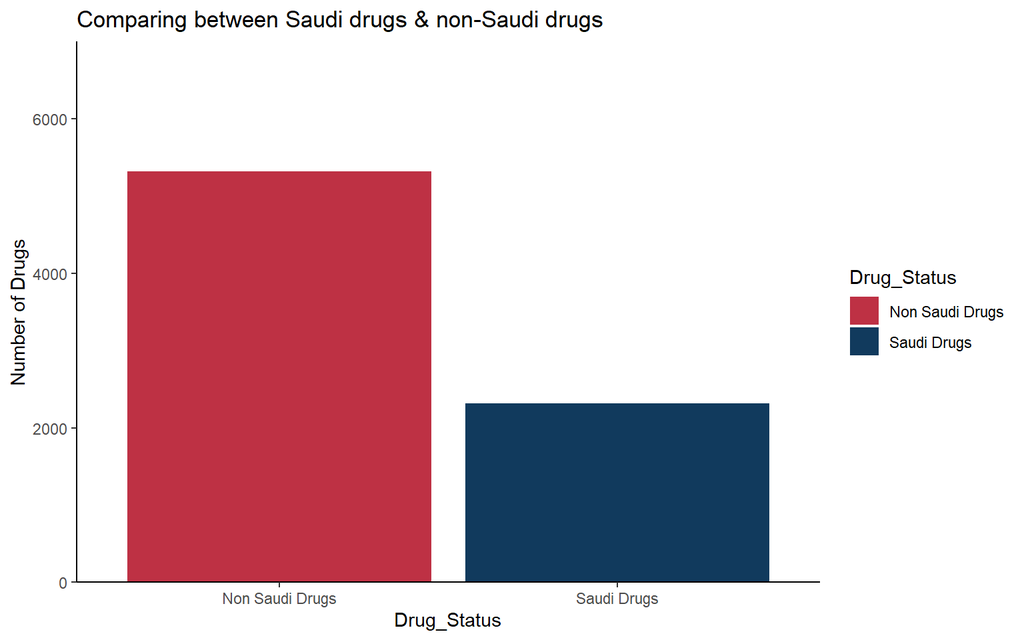

| Drug_Status | percent |
| --- | --- |
| Non Saudi Drugs | 69.67911 |
| Saudi Drugs | 30.32089 |

overall, Saudi drugs contributes to only 30% of registered drugs.

#### Exclusive Drugs:

222 drugs are synthesized exclusively. 1252 drugs synthesized only outside SA, as we have 1782 different drugs, It is 70% of total distinct drugs. However looking to Saudi drug list, there are so different combinations of electrolytes, there also might be some spelling issues which may slightly affect the result for both arms

#### RegisterYear

Year of drug registration

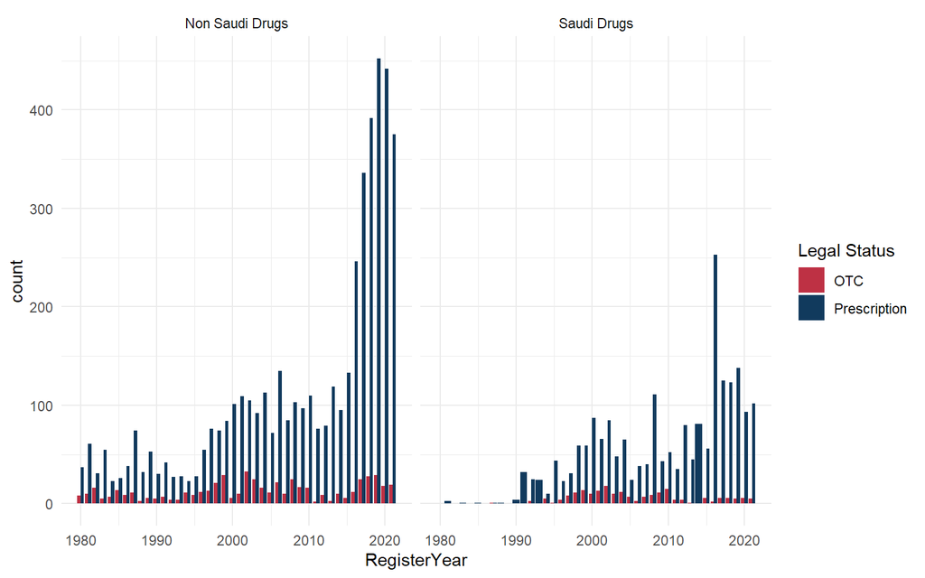

Starting of Saudi company was almost after 90s, before that, it was markted by other countries. The peak in recent years, the presences of covid-19 might affect increasing drug registration especially for non-Saudi drugs.

#### Public Price

```
##   Public price
##  Min.   :      0.0
##  1st Qu.:     17.2
##  Median :     45.0
##  Mean   :   1331.9
##  3rd Qu.:    151.5
##  Max.   :1759274.3
##  NA's   :3
```

the data for price has extreme values could starts from 0 price (influenza vaccine) to a very high price 1759274.3 which make it impossible to draw in meaningful graph, that is issue solved by Shiny app which you can navigate the prices for each country in one plot without too much overlapping!

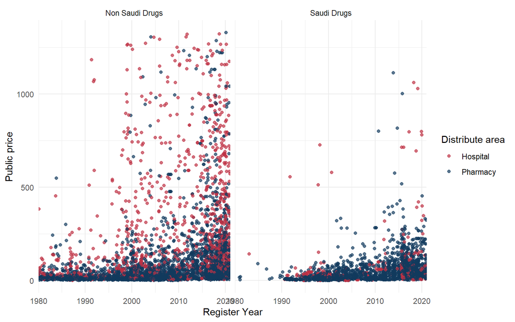

in general, higher prices in recent years for hospital distribution,

pleas note that I determined the price based on mean, however the mean is affected by extreme values, although the 3rd Qu 151.5. There are 212 missing values in the plot which cover less than 3% of the data.

Histogram for price!

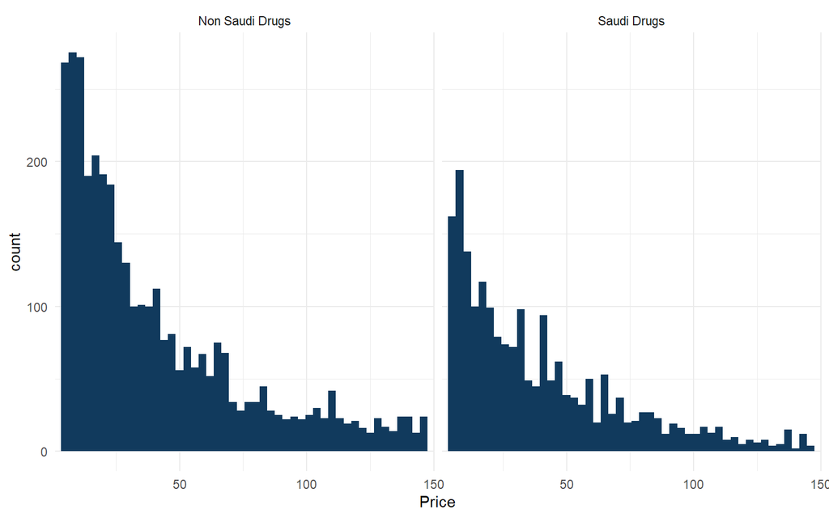

more cheaper medications is synthesized

#### DrugType

almost 2/3 of drugs are generic followed by A New Chemical Entity drugs.

| DrugType | n |
| --- | --- |
| Generic | 4735 |
| NCE | 2263 |
| Biological | 620 |
| Radiopharmaceutical | 6 |
| Health | 4 |

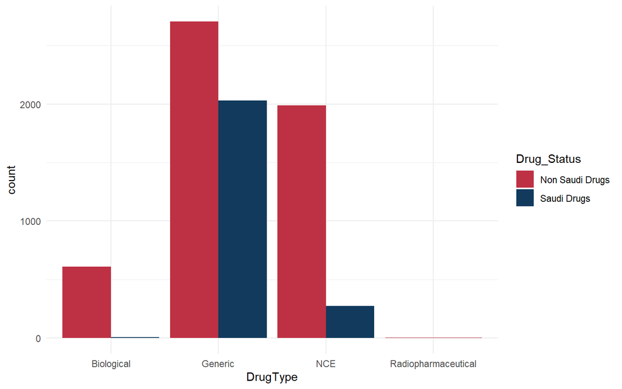

most common drugs are Generic or NCE, It makes a sense because biological and radiophamaceticals are since these drugs used in serious diseases such as cancer! description of each type

1- A generic drug is a medication that has exactly the same active ingredient as the brand name drug and yields the same therapeutic effect.[(the link)](https://www.bing.com/search?q=what+is+genric++drugs&go=Search&qs=ds&form=QBRE)

2- A New Chemical Entity (NCE) is a drug that does not contain any active moiety that has been approved by FDA with any other application. The manufacturers of an innovator drug generally develop a NCE during the early development stage of the product cycle. The NCE, then, undergoes various clinical trials in order to transform into a drug product[(the link)](https://www.freyrsolutions.com/what-is-new-chemical-entity-nce).

3- Biological drugs (commonly referred to as ‘biologics’ or ‘biopharmaceuticals’) are drugs produced through biological processes. They currently target diseases which, hitherto, had very limited or no available treatment options – including several types of cancers, autoim- mune diseases and other non-communicable diseases(the link).

4- Radiopharmaceuticals are radioactive chemicals or pharmaceutic preparations, labeled with a radionuclide in tracer or therapeutic concentration [(the link)](https://www.bing.com/search?q=radiopharmaceutical+drugs&cvid=d7f86b4972624a218438fbe54ef7413a&aqs=edge.3.69i57j0l8.6607j0j4&FORM=ANAB01&PC=ASTS).

Comparing Drug type against price

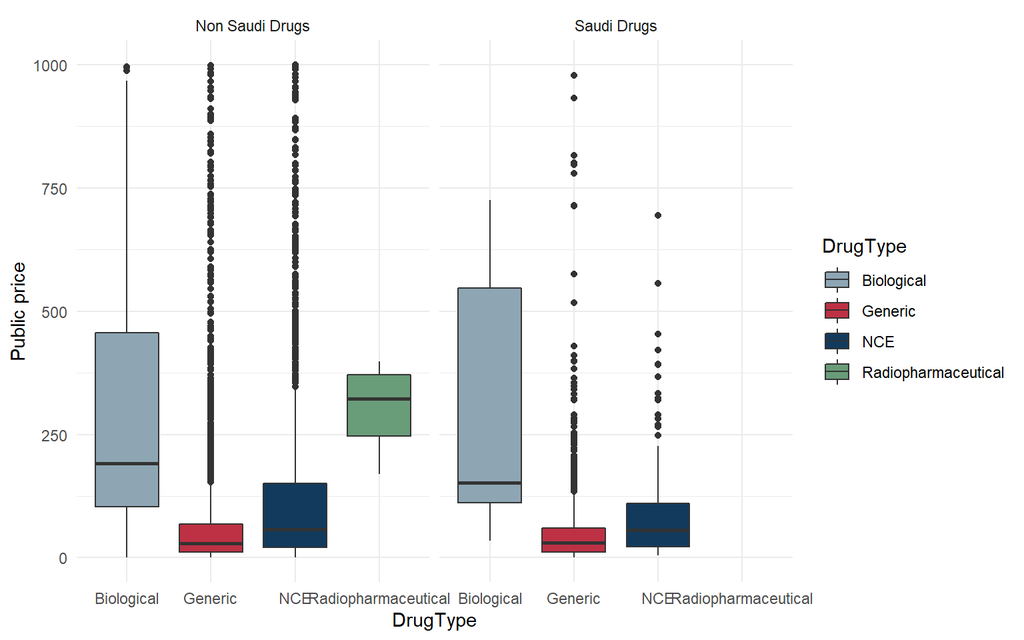

biological drugs have higher prices. typically They mimic proteins and other molecules found in living organisms and can target harmful entities, such as some cancer cells, with great accuracy; many of the most promising new drugs for cancer and other diseases fall into this class. Biological drugs tend to be larger, more complex molecules than drugs synthesized through chemical reactions, which adds to production challenges and makes them costly.

#### ADMINSTRATION ROUTE

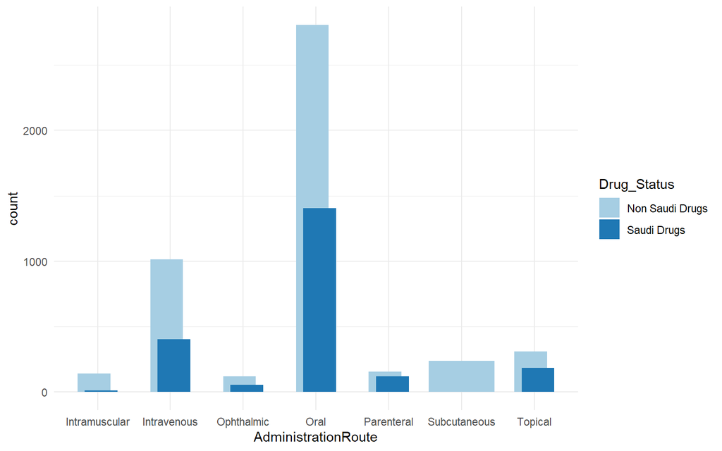

finding our focus

Saudi manufacturer focus more on oral drugs followed by Iv drugs but then what kind of iv drug provided?

| Scientific Name | Trade Name |
| --- | --- |
| dextrose, sodium chloride | 63 |
| dextrose | 58 |
| sodium chloride | 21 |
| water | 18 |
| sodium bicarbonate | 12 |
| magnesium chloride6h2o, potassium chloride , acetic acid , calcium chloride 2h2o , dextrose , sodium chloride | 9 |
| balanced electrolytes | 8 |
| magnesium chloride6h2o , potassium chloride , acetic acid , calcium chloride 2h2o , dextrose , sodium chloride | 8 |
| potassium chloride, sodium chloride | 8 |
| potassium chloride | 7 |

ok, that’s what I expect, manufacturers focus really on basic treatment which is not not be specific to any disease. we have also import electrolytes &Normal saline from other countries.  
let us try on oral medications

#### Top 10 oral manufactured drugs

| Scientific Name | Trade Name |
| --- | --- |
| pregabalin | 41 |
| tadalafil | 29 |
| levetiracetam | 27 |
| montelukast sodium | 26 |
| etoricoxib | 22 |
| olanzapine | 21 |
| quetiapine fumarate | 21 |
| azithromycin | 20 |
| sildenafil citrate | 20 |
| glimepiride | 18 |

This is gives us better idea than IV drugs pregabalin in the top,anticonvulsant and anxiolytic medication used to treat epilepsy, neuropathic pain, fibromyalgia, restless leg syndrome, and generalized anxiety disorder. Also, it used for diabetic neuropathy. pregabalin in last 5 years this drug has been added to controlled drugs because they found that it cause addiction. Many patients still addict to this medication. so it is consumer need! 24 drug registration of pregabalin after become controlled

- Montelukast used as prophylaxis and chronic treatment of asthma and Allergic or Perennial Rhinitis which is expected because of our dusty weather
- Tadalfil & Sildenafil used in pulmonary hypertension and impotence
- Levetiracetam is anti-epliptic
- Olanzapine $ Quetiapine is anti-psychiatric medications. they can be overuse but it is indicator of mental health issues
- Glimepiride, finally we got is an anti-diabetic medication!  
  Honestly, I was expected antidiapetic & antihypertensive medication to be in the top, our hospitals are full of diabetic & hypertensive patients

#### Top 10 oral imported drugs

| Scientific Name | Trade Name |
| --- | --- |
| quetiapine fumarate | 40 |
| amoxicillin, clavulanic acid | 34 |
| ciprofloxacin | 32 |
| montelukast sodium | 28 |
| etoricoxib | 27 |
| tadalafil | 25 |
| glimepiride | 24 |
| clarithromycin | 23 |
| ibuprofen | 22 |
| paracetamol | 22 |

#### Comment on mental health on Saudi Arabia

the first national study of COVID-19 impact on mental health from Saudi Arabia, the risk of depression in Saudi Arabia increased by 71.2% between May and August 2020 compared to 2018. Other studies demonstrated that The risks of major depressive disorder and generalized anxiety disorder are relatively high. studies within the Reference

#### Top 10 Intramuscular Saudi Manufacuerd drugs

| Scientific Name | Trade Name |
| --- | --- |
| ceftriaxone | 4 |
| cefazolin | 2 |
| cefepime | 1 |
| cefotaxime | 1 |
| chorionic gonadotrophin (hcg) | 1 |
| diphtheria, hemophilus influenzae b, pertussis, tetanus, hepatitis b | 1 |
| ketoprofen | 1 |
| piroxicam | 1 |
| vitamin b6 (pyridoxine ) , vitamin b1 (thiamine hydrochloride) , vitamin b12 (cyanocobalamin) | 1 |

the top 4 drugs are antibiotic

### Manufacturer Countries

top 10 Manufacturer Countries

| Manufacture Country | n |
| --- | --- |
| Saudi Arabia | 2315 |
| Jordan | 629 |
| Germany | 562 |
| United States | 452 |
| United Arab Emirates | 319 |
| United Kingdom | 317 |
| France | 290 |
| Italy | 287 |
| India | 268 |
| Switzerland | 238 |

drugs imported mainly from Jordon followed by Germany

#### Shelf life

length of time that a drug can be stored in months. It differ than expiration date. From medical perspective: The shelf life generally relates to a drug’s quality over a specified period of time, whereas the expiration date relates to both quality and safety of a medication at a specific point in time[(the link)](https://specialties.bayt.com/en/specialties/q/7932/what-is-the-difference-between-expiry-date-and-shelf-life/).

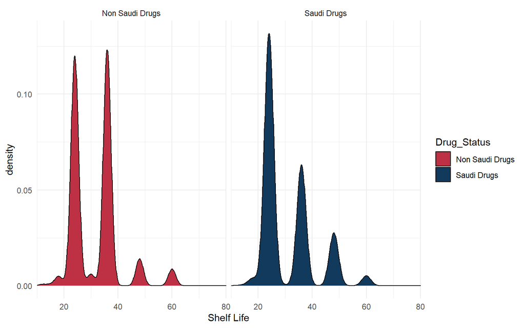

## General Information

### Top 10 Highly consumed Drugs

many trade drugs for same generic drugs means that is highly consumed

| Scientific Name | Trade Name |
| --- | --- |
| sodium chloride | 111 |
| dextrose, sodium chloride | 82 |
| dextrose | 78 |
| diclofenac sodium | 63 |
| amoxicillin, clavulanic acid | 62 |
| paracetamol | 62 |
| quetiapine fumarate | 61 |
| ciprofloxacin | 55 |
| montelukast sodium | 54 |
| tadalafil | 54 |

**Sodium Chloride** Normal saline, it is widely used in the hospitals which make a sense that is the most common one

**DExtrose** Also widely used, it is simple sugar, so mainly used for Hypoglycemia, it is used along with Sodium cloride

**Paracetamol & diclofinac** both are pain killers, both are widely used inside and outside hospitals, both have oral form, In general, Diclofinac is available also as intermuscular which make it prefered mild to moderate pain killer in the ER rather than parecetamol (IV) which may take longer time.

**amoxicillins&clavunic acid** β-lactam antibiotics (beta-lactam antibiotics), it has wide antibactrial spectrum covering & it taken orally, generally it can treat: : Ear, Nose, & Throat Infections,Genitourinary Tract Infections,Skin & Skin Structure Infections,Lower Respiratory Tract Infections

**quetiapine** it is used for psychiatric disorders such as: Major Depressive Disorder, Schizophrenia,Bipolar I Disorder & insomnia

**ciprofloxacin** Fluoroquinolones antibiotics, unlike amoxicillin which is available only in oral dose, cipro also has IV form which make it suitable for inpatients hospitals, it covers lower respiratory tract infections such as Pneumonia, urinary tract infections (UTI), bone & skin infection.

**montelukast** it is used as prophylaxis and chronic treatment of asthma and Allergic or Perennial Rhinitis

### What are the top 10 registered priced drugs?

| Public price | Scientific Name | DrugType | RegisterYear | Manufacture Country | AdministrationRoute |
| --- | --- | --- | --- | --- | --- |
| 1759274.32 | voretigene neparvovec | Biological | 2020 | United Kingdom | NA |
| 1633500.00 | tisagenlecleucel | Biological | 2020 | United States | Intravenous |
| 394762.50 | nusinersen | NCE | 2019 | Italy | INTRATHECAL |
| 95189.65 | eliglustat | NCE | 2018 | Ireland | Oral |
| 83063.45 | catridecacog | NCE | 2015 | Denmark | Intravenous |
| 77094.89 | larotrectinib | NCE | 2020 | United Kingdom | Oral |
| 72568.25 | grazoprevir, elbasvir | NCE | 2016 | Ireland | Oral |
| 65083.35 | ipilimumab | Biological | 2015 | United States | Intravenous |
| 56854.95 | erdafitinib | NCE | 2021 | Italy | Oral |
| 52774.45 | lanadelumab | Biological | 2020 | United States | Subcutaneous |

**Voretigene Neparvovec** is an adeno-associated viral gene therapy used to treat biallelic RPE65 mutation associated retinal dystrophy it is subretinal injection. FDA aprroved in 2017

**Tisagenlecleucel**sold under the brand name Kymriah, is a medication for the treatment of B-cell acute lymphoblastic leukemia (ALL) which uses the body’s own T cells to fight cancer (adoptive cell transfer).Acute lymphoblastic leukemia in children is more common than other types of cancer

**nusinersen** used in treating spinal muscular atrophy (SMA), a rare neuromuscular disorder.In December 2016, it became the first approved drug used in treating this disorder.

**eliglustat** used for the long-term treatment of Gaucher disease type 1

**catridecacog** indicated in patients with a rare clotting disorder, congenital factor XIII A-subunit deficiency, which is a kind of Factor XIII deficiency. The drug prevents bleeding in patients with this condition, and has been approved FDA in 2014.

**larotrectinib** used for adults and children with solid tumors that test positive for NTRK genes, which can help cancerous tumors grow. Tumors with this type of genetic change are not common but can be found in cancers of the salivary gland, thyroid, lung, and soft tissue sarcoma

**grazoprevir** Antiviral drug for chornic heptits c infection, hepatitis C protease inhibitor.

**ipilimumab** biological drugs to treat late-stage melanoma that has spread or cannot be removed by surgery

**erdafitinib**treat adults with bladder cancer (urothelial cancer) that has spread or cannot be removed by surgery:

**Lanadelumab**promote prevention of angioedema in patients with hereditary angioedema.

### country map

#### Top priced drug for each manufucure country registered in SFDA

[interactive chart not shown]

The map is interactive, You can see all countries with the highest price for each drug!

### what are suspended drugs

| Scientific Name | Manufacture Country | RegisterYear | Legal Status |
| --- | --- | --- | --- |
| omeprazole | Belgium | 2009 | Prescription |
| glimepiride | United Arab Emirates | 2012 | Prescription |
| glimepiride | United Arab Emirates | 2011 | Prescription |
| glimepiride | United Arab Emirates | 2011 | Prescription |
| metformin | United Arab Emirates | 2009 | Prescription |
| clarithromycin | United Arab Emirates | 2002 | Prescription |
| simethicone (activated dimethicone) | Switzerland | 2015 | OTC |
| venlafaxine | Saudi Arabia | 2018 | Prescription |
| venlafaxine | Saudi Arabia | 2018 | Prescription |
| pantoprazole sodium sesquihydrate | Egypt | 2017 | Prescription |
| pregabalin | Saudi Arabia | 2017 | Prescription |
| pregabalin | Saudi Arabia | 2017 | Prescription |
| esomeprazole magnesium | Saudi Arabia | 2019 | Prescription |
| esomeprazole magnesium | Saudi Arabia | 2019 | Prescription |
| esomeprazole magnesium | Saudi Arabia | 2019 | Prescription |
| esomeprazole magnesium | Saudi Arabia | 2019 | Prescription |

it seems that all of suspneded drugs might have manufacture issues or any other issues rather than a problem in a drug itself, since all drugs are still in use

## References

Sfda.gov.sa. 2021. Overview | Saudi Food and Drug Authority. [online] Available at: https://www.sfda.gov.sa/en/overview [Accessed 13 November 2021].

Institute for Health Metrics and Evaluation. 2021. Saudi Arabia. [online] Available at: http://www.healthdata.org/saudi-arabia [Accessed 13 November 2021].

World Life Expectancy. 2021. HEALTH PROFILE SAUDI ARABIA. [online] Available at: https://www.worldlifeexpectancy.com/country-health-profile/saudi-arabia [Accessed 13 November 2021].

BinDhim, N. F., Althumiri, N. A., Basyouni, M. H., Alageel, A. A., Alghnam, S., Al-Qunaibet, A. M., … & Ad-Dab’bagh, Y. (2021). Saudi Arabia Mental Health Surveillance System (MHSS): Mental health trends amid COVID-19 and comparison with pre-COVID-19 trends. European Journal of Psychotraumatology, 12(1), 1875642. https://www.tandfonline.com/doi/full/10.1080/20008198.2021.1875642

Altwaijri, Y. A., Al‐Subaie, A. S., Al‐Habeeb, A., Bilal, L., Al‐Desouki, M., Aradati, M., … & Kessler, R. C. (2020). Lifetime prevalence and age‐of‐onset distributions of mental disorders in the Saudi National Mental Health Survey. International journal of methods in psychiatric research, 29(3), e1836. https://onlinelibrary.wiley.com/doi/full/10.1002/mpr.1836